# Using flowmix to analyze flow cytometry data

29 August 2022

# 1 Introduction

`flowmix` is an R package containing code for analyzing flow cytometry data using the “flowmix” model – a sparse constrained multivariate mixture of regressions model. this model is appropriate to use when you have a collection of flow cytometry datasets $y^{(t)}$ *and* p-variate *covariates* $X^{(t)} \in \mathbb{R}^p$ – more about this notation and setup is shown below in the “Model” section.

The original paper can be found here: https://arxiv.org/abs/2008.11251 (Accepted to the Annals of Applied Statistics).

# 2 Installation

Simple installation instructions go here.

```r
if (!require("BiocManager", quietly = TRUE))
    install.packages("BiocManager")
BiocManager::install("BiocStyle")
```

# 3 Model

**Basic model.** Consider response data $y^{(t)}$ and covariate $X^{(t)} \in \mathbb{R}^{p}$ observed over time $t = 1,\cdots, T$.

In our setup, $y^{(t)}$ is a collection of $n_t$ $d$-variate data points $y_i^{(t)}$. Because our main application is flow cytometry which measures cell-level attributes in a fluid, we will call these particles, and $y^{(t)}$ cytograms.

Now, conditional on covariate $X^{(t)}$ at time $t$, each particle is modeled to come from a probabilistic mixture of $K$ different d-variate Gaussians:

$$y^{(t)}_i | X^{(t)} \sim \mathcal{N}_d \left(\mu_{kt}, \Sigma_k\right)
\text{ with probability } \pi_{kt},$$

where $\pi_{kt}$ is the $k$’th cluster’s relative abundance at time $t$, and $\mu_{kt}$ is the $k$’th cluster center at time $t$.

For each $k=1,\cdots, K$, cluster centers $\mu_{kt} \in \mathbb{R}^d$ and cluster probabilities $\pi_{kt}$ at time $t$ are modeled as functions of $X^{(t)}$:

$$\mu_{kt} = \beta_{0k} + \beta_k^T X^{(t)}$$

and

$$\pi_{kt} = \frac{\exp(\alpha_{0k} + {X^{(t)}}^T \alpha_k)}{\sum_{l=1}^K \exp(\alpha_{0l} + {X^{(t)}}^T \alpha_l)}$$

for regression coefficients $\beta_{0k} \in \mathbb{R}^d$, $\beta_{k} \in \mathbb{R}^{p \times d}$, $\alpha_k \in \mathbb{R}^p$, and $\alpha_{0k} \in \mathbb{R}$ The covariance $\Sigma_k$ determines shape of $k$’th Gaussian cluster, and is assumed to be constant over time, and not determined by covariates.

**Sparse coefficient estimation.** The aforementioned model has $(p+1)(d+1)K$ regression coefficients, which can be large compared to the number of cytograms $T$. So we penalize the log-likelihood with lasso penalties on $\alpha$ and $\beta$, which induce sparsity on these coefficients, thus enhancing interpretation and making the model identifiable. The two regularization parameters are $\lambda_{\alpha}$ and $\lambda_{\beta}$ govern the level of sparsity, and are estimated using cross-validation.

**Limiting cluster mean movement.** Also, in our ocean application, each cell population has a limited range in optical properties, due to biological constraints. We incorporate this domain knowledge into the model by constraining the range of $\mu_{k1}, \cdots, \mu_{kT}$ over time. Since $\beta_k^TX^{(t)} = \mu_{kt} - \beta_{0k}$, limiting the size of $\beta_k^TX^{(t)}$ is equivalent to limiting the *deviation* of the $k$’th cluster mean at all times $t=1,\cdots,T$ away from the overall center $\beta_{0k}$. Motivated by this, we add a constraint so that $\|\beta_k^T X^{(t)}\|_2 \le r$ for some fixed radius value $r>0$.

The constraint also plays an important role for model interpretability. We wish for the $k$’th mixture component to correspond to the same cell population over all time. When a cell population vanishes we would like $\pi_{kt}$ to go to zero rather than for $\mu_{kt}$ to move to an entirely different place in cytogram space.

Lastly, the model estimates are obtained using a penalized expectation-maximization (EM) algorithm, which is optimized to be fast.

For more details about the model and algorithm, please refer to the full paper: [link](https://arxiv.org/abs/2008.11251).

Next, we use artificial and real data to demonstrate how to use the package. The main function is `flowmix()`.

# 4 Examples

```r
library(flowmix)
library(tidyverse)
library(RColorBrewer)
```

## 4.1 Artificial data

First, generate data:

```r
set.seed(0)
datobj = generate_data_generic(p = 5, TT = 300, fac = .2, nt = 2000, dimdat = 3) #
ylist = datobj$ylist
X = datobj$X
```

This produces three dimensional cytograms `ylist` and covariates `X`.

The first cytogram $y^{(1)}$ looks like this (only plotting the first two dimensions, out of three).

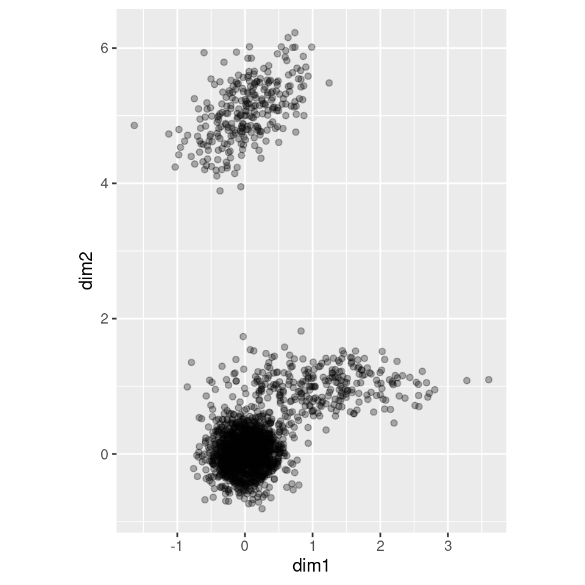

```r
y = ylist[[1]][,1:2]
colnames(y) = c("dim1", "dim2")
as_tibble(y) %>%
  ggplot() + geom_point(aes(x=dim1, y = dim2), alpha = .3) +
  coord_fixed()
```

Especially if your data is a time series, it could be useful to plot the covariates $X^{(t)}$ once across time $t=1,\cdots, T$.

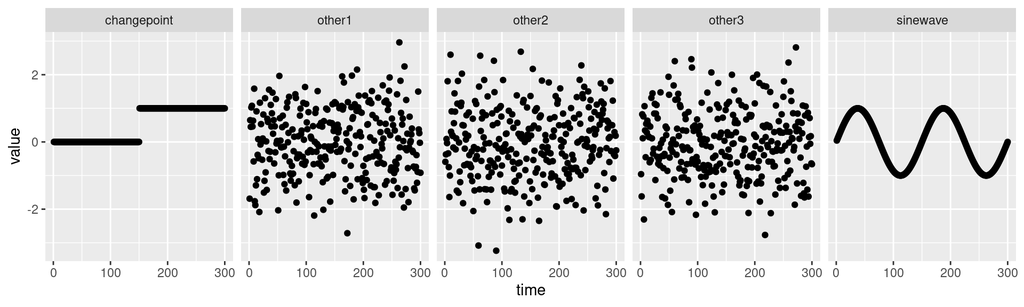

```r
colnames(X) = c("sinewave", "changepoint", "other1", "other2", "other3")
as_tibble(X) %>%
  add_column(time = 1:nrow(X)) %>%
  pivot_longer(cols = !time)  %>%
  ggplot(aes(x=time, y=value)) +
  facet_grid(.~name) +
  geom_point()
```

Internally, `flowmix()` repeats the estimation five times (five is the default) with different random restarts, and returns the estimated model out of five runs with the best data fit.

```r
numclust = 4
set.seed(0)
res = flowmix(ylist = ylist, X = X, numclust = numclust,
              mean_lambda = 0.001, prob_lambda = 0.001,
              nrep = 1)
print(res)
```

```
#> [1] "45 out of 60 regression coefficients for the cluster centers, are zero."
#> [1] "19 out of 20 regression coefficients for the cluster probabilities, are zero."
#> [1] "The algorithm converged in 20 EM iterations."
```

The cluster probabilities over time look like this:

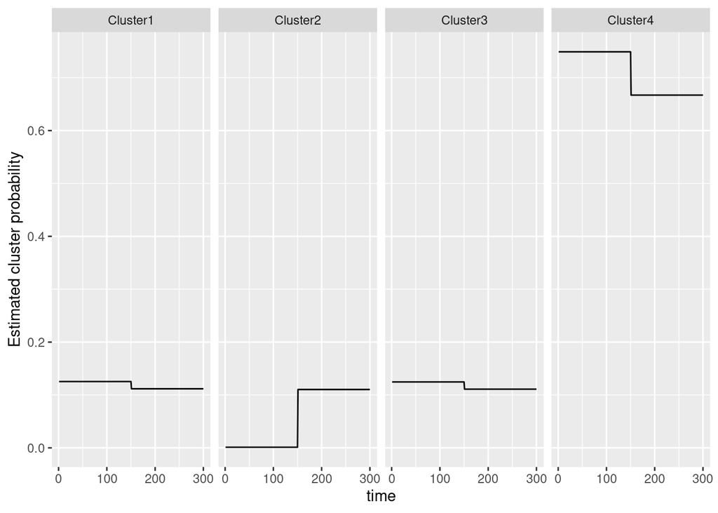

```r
prob = res$prob
colnames(prob) = paste0("Cluster", 1:numclust)

as_tibble(prob) %>%
  add_column(time = 1:nrow(prob)) %>%
  pivot_longer(cols = !time)  %>%
  ggplot(aes(x=time, y=value)) +
  facet_grid(.~name) +
  geom_line() +
  ylab("Estimated cluster probability")
```

Showing the model estimates across time, in an animation.

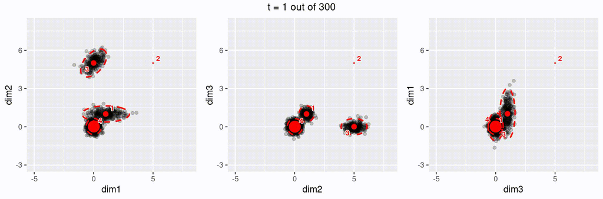

```r
## Make all 2d plots
ylim = c(-3,8)
xlim = c(-5,8)
for(tt in seq(from=1, to = 300, by = 30)){
  plist = lapply(list(c(1,2), c(2,3), c(3,1)), function(dims){

    ## Take the model estimates for dimensions in \code{dims}
    mn = res$mn[tt,dims,]
    sigma = res$sigma[,dims,dims]
    prob = res$prob[tt,]

    ## Plot them in a figure
    y = ylist[[tt]][,dims]
    varnames = paste0("dim", dims)
    varname1 = varnames[1]
    varname2 = varnames[2]
    colnames(y) = varnames
    y = y %>% as_tibble()
    p = ggplot(y, aes(x = !!sym(varname1), y = !!sym(varname2))) +
      geom_point(alpha = 0.2) +
      ylim(ylim) +
      xlim(xlim)

    ## Add model
    p1 = add_model_2d(p, mn, sigma, prob)
    return(p1)
  })

  gridExtra::grid.arrange(plist[[1]], plist[[2]], plist[[3]], nrow = 1,
                          top = paste0("t = ", tt, " out of ", res$TT))
}
```

## 4.2 Cross-validation

`cv.flowmix` conducts cross-validation among the candidate regularization parameters in numeric vectors `prob_lambdas` and `mean_lambdas` ($\lambda_\alpha$ and $\lambda_\beta$). These can be obtained numerically like this:

```r
## Define the locations to save the CV results.
destin = "."

## Define the CV folds (as every fifth, nfold-sized, block of indices)
folds = make_cv_folds(ylist, nfold = 5, blocksize = 20)

## This saves to a file `maxres.Rdata` under the |destin| directory.
maxres = get_max_lambda(destin,
                        "maxres.Rdata",
                        ylist = ylist,
                        countslist = NULL,
                        X = X,
                        numclust = 4,
                        maxdev = 0.5,
                        max_mean_lambda = 40,
                        max_prob_lambda = 2)
```

```
#> [1] "2022-08-29 21:30:35 PDT"
#> Maximum regularization values being calculated.
#> with initial lambdas values (alpha and beta):
#> [1]  2 40
#> [1] "running the models once"
#> ###############################################################
#> #### lambda_alpha =  2  and lambda_beta =  40 being tested.
#> ###############################################################
#>
#> ###############################################################
#> #### lambda_alpha =  1  and lambda_beta =  20 being tested.
#> ###############################################################
#>
#> ###############################################################
#> #### lambda_alpha =  0.5  and lambda_beta =  10 being tested.
#> ###############################################################
#>
#> ###############################################################
#> #### lambda_alpha =  0.25  and lambda_beta =  5 being tested.
#> ###############################################################
#>
#> ###############################################################
#> #### lambda_alpha =  0.125  and lambda_beta =  2.5 being tested.
#> ###############################################################
#>
#> ###############################################################
#> #### lambda_alpha =  0.0625  and lambda_beta =  1.25 being tested.
#> ###############################################################
#>
#> ###############################################################
#> #### lambda_alpha =  0.03125  and lambda_beta =  0.625 being tested.
#> ###############################################################
#> file was written to  ./maxres.Rdata
#> maximum regularization value calculation done.
#> [1] "2022-08-29 21:32:50 PDT"
```

```r
cv_gridsize = 5
prob_lambdas =  logspace(min = 0.0001, max = maxres$alpha, length = cv_gridsize)
mean_lambdas = logspace(min = 0.0001, max = maxres$beta, length = cv_gridsize)
```

[output not shown]

Also define the CV folds. You can choose not to, by setting `folds=NULL`, in which case the default folds are used.

```r
## Define the CV folds (as every fifth, nfold-sized, block of indices)
folds = make_cv_folds(ylist, nfold = 5, blocksize = 20)
```

Now, run the cross-validation using `cv.flowmix()`.

```r
cvres = cv.flowmix(ylist = ylist,
                   countslist = NULL,
                   X = X,
                   maxdev = 0.5,
                   numclust = 4,
                   prob_lambdas = prob_lambdas,
                   mean_lambdas = mean_lambdas,
                   nrep = 10,
                   folds = folds,
                   destin = destin,
                   mc.cores = 8)
```

(This code takes long, so it’s recommended that you run it separately in a script; use the `mc.cores` option to run the jobs on multiple cores):

The results are saved into separate files whose names follow these rules: - “1-1-1-1.Rdata” for `ialpha`-`ibeta`-`irep`-`ifold`.Rdata, having run the CV. - “1-1-1-cvres.Rdata” for having estimated the model in the full data

After the cross-validation is finished, the final selected model is summarized from these files, and optionally saved to a file `summary.RDS` (if `save=TRUE`):

```r
cvres = cv_summary(destin = destin,
                   cv_gridsize = 5,
                   nrep = 10,
                   nfold = 5,
                   save = TRUE,
                   filename = "summary.RDS")
```

We can see the final model chosen by cross-validation like this:

```r
print(cvres$bestres)
```

## 4.3 Real data

Now, trying this on real (binned) data:

```r
## Load data
## datobj = readRDS(file = "~/repos/flowmix/paper-data/MGL1704-hourly-paper.RDS")
datobj = readRDS(file = "../inst/extdata/MGL1704-hourly-paper.RDS") ## change to readRDS(system.file("extdata", "MGL1704-hourly-paper.RDS"))
datobj %>% list2env(envir = .GlobalEnv) %>% invisible()

## Estimate model
set.seed(1)
res = flowmix(ylist, X, numclust = 10,
              countslist = countslist,
              mean_lambda = 0.001,
              prob_lambda = 0.001,
              maxdev = 0.5,
              nrep = 1,
              verbose = FALSE)
```

See the appendix below for more about binning data.

Also, here we have used a fixed, hand-picked pair of regularization parameter values `mean_lambda` and `prob_lambda`. In practice, you’ll want to cross-validate.

We can visualize the estimated model in several ways. First, the default `print()` gives a summary about the coefficients’ sparseness.

```r
print(res)
```

```
#> [1] "847 out of 1170 regression coefficients for the cluster centers, are zero."
#> [1] "306 out of 390 regression coefficients for the cluster probabilities, are zero."
#> [1] "The algorithm converged in 35 EM iterations."
```

The probabilities in `res$prob` can be visualized as follows.

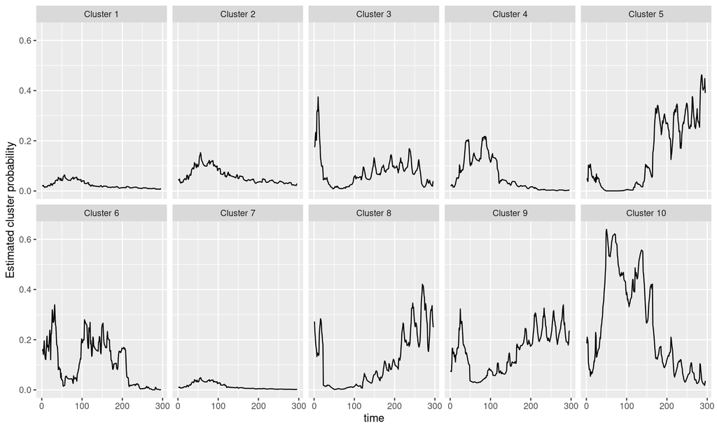

```r
numclust = 10
prob = res$prob
colnames(prob) = paste0("Cluster ", 1:numclust)
prob_long = as_tibble(prob) %>%
  add_column(time = 1:nrow(prob)) %>%
  pivot_longer(cols = !time)
prob_long$name = factor(prob_long$name, paste0("Cluster ", 1:numclust))

prob_long %>%
  ggplot(aes(x = time, y = value)) +
  facet_wrap(~name, ncol = 5) +
  geom_line() +
  ylab("Estimated cluster probability")
```

Lastly, the model means and 95% confidence regions in `res$mn` can be visualized – two dimensions at a time, overlaid with data – as follows.

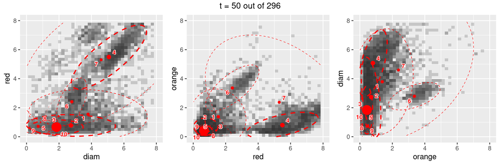

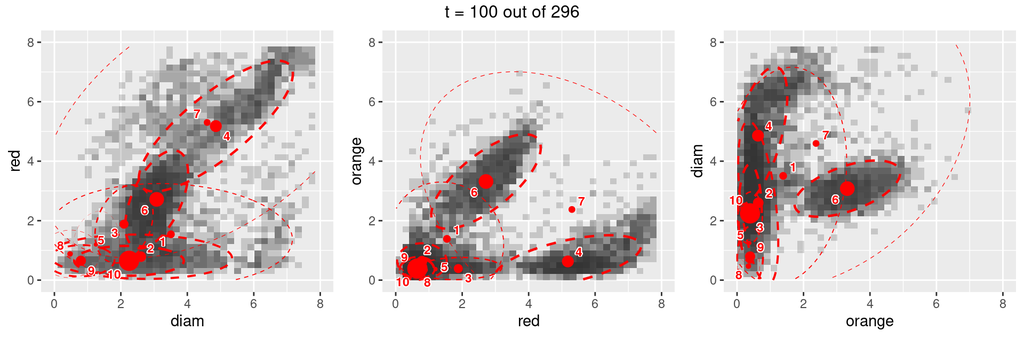

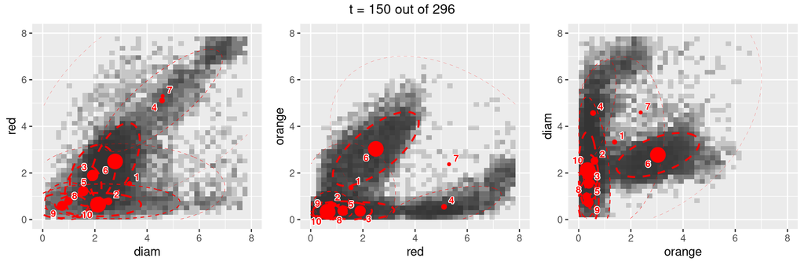

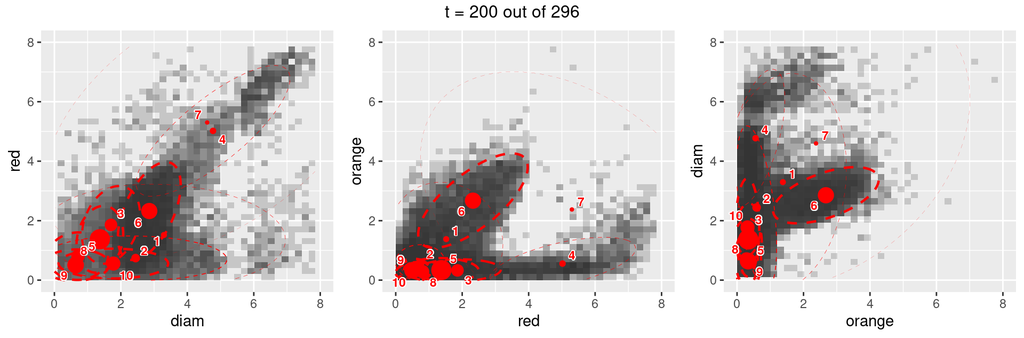

```r
dimnames = c("diam", "red", "orange")
## for(tt in seq(from=1, to = 296, by = 10)){
for(tt in c(50,100,150,200)){
  plist = lapply(list(c(1,2), c(2,3), c(3,1)), function(dims){

    ## Take the model estimates for dimensions in \code{dims}
    mn = res$mn[tt,dims,]
    sigma = res$sigma[,dims,dims]
    prob = res$prob[tt,]

    ## Plot them in 2d
    y = ylist[[tt]][,dims]
    varnames = dimnames[dims] ##paste0("dim", dims)
    varname1 = varnames[1]
    varname2 = varnames[2]
    colnames(y) = varnames
    y = y %>% as_tibble()
    p = ggplot(y, aes(x = !!sym(varname1), y = !!sym(varname2))) +
      geom_tile(alpha = 0.2) +
      ylim(c(0,8)) +  xlim(c(0,8))

    ## Add model
    p = add_model_2d(p, mn, sigma, prob)
    return(p)
  })
  gridExtra::grid.arrange(plist[[1]], plist[[2]], plist[[3]], nrow = 1,
                          top = paste0("t = ", tt, " out of ", res$TT))
}
```

# 5 Appendix

## 5.1 Binning data

If the data contains too many particles, it is better to reduce the size of `ylist` and instead deal with binned counts.

The new object `countslist` can be *additionally* input to `flowmix()`.

Here is an example. `make_grid(ylist, gridsize=30)` makes an equally sized grid of size 30 from the data range, in each dimension. Then, `bin_many_cytograms()` places the particles in `ylist` in each of these bins. The resulting object is a list which contains the grid centers `ybin_list` and the counts in each `counts_list`.

(It’s not demonstrated here, but apart from binning data, another use for `countslist` is to describe the biomass of each particle.)

```r
## Generate synthetic particle-level (non-binned) data
set.seed(0)
datobj = generate_data_generic(p = 5, TT = 100, fac = .2, nt = 2000, dimdat = 3)
ylist = datobj$ylist
X = datobj$X
y = ylist %>% .[[1]] %>% as_tibble()
```

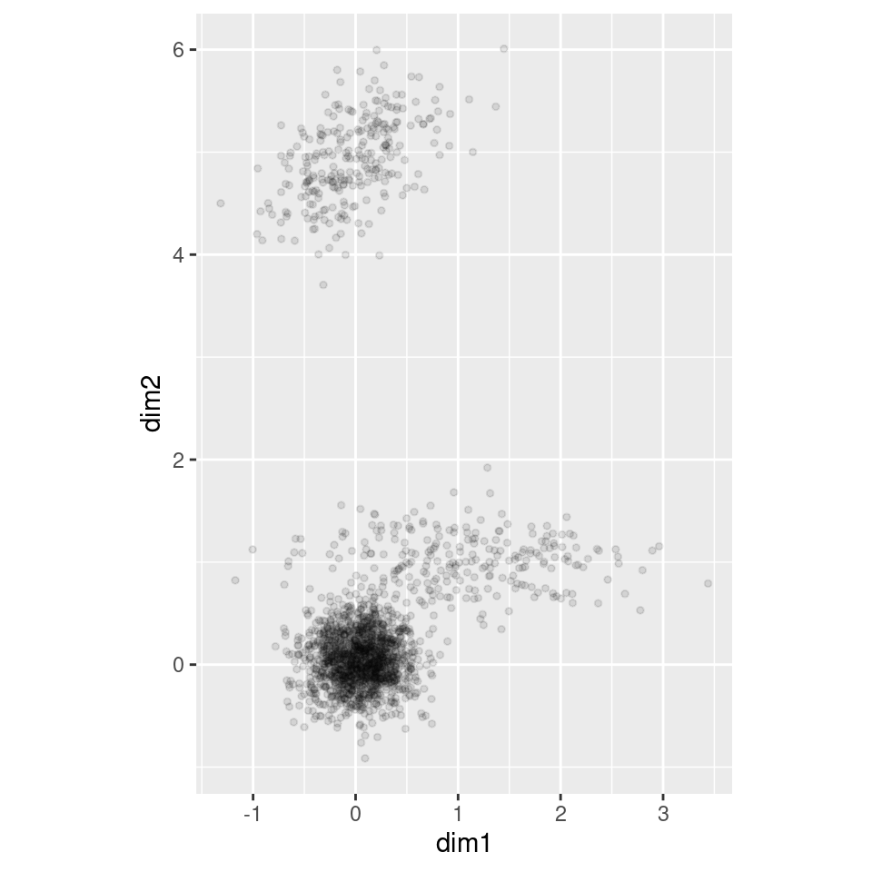

```r
colnames(y) = c("dim1", "dim2", "dim3")

## Plot data before binning
p = ggplot(y) +
  geom_point(aes(x=dim1, y=dim2), alpha = .1, size = rel(1)) +
  coord_fixed()
plot(p)
```

Then, bin the particle-level data using `bin_many_cytograms()`.

```r
## Bin this data
grid = make_grid(ylist, gridsize = 30)
obj = bin_many_cytograms(ylist, grid, mc.cores = 4, verbose=FALSE)
ylist = obj$ybin_list
countslist = obj$counts_list

ylist[[1]] %>% head(15) %>% round(3) %>% print()
```

```
#>
#>  [1,] -1.218  0.931  1.121
#>  [2,] -1.218  4.473  0.147
#>  [3,] -0.936  1.203  1.365
#>  [4,] -0.936  4.200  0.147
#>  [5,] -0.936  4.473 -0.584
#>  [6,] -0.936  4.473 -0.340
#>  [7,] -0.936  4.473  0.147
#>  [8,] -0.936  4.745 -0.097
#>  [9,] -0.655 -0.431 -0.584
#> [10,] -0.655 -0.431 -0.340
#> [11,] -0.655 -0.431  0.147
#> [12,] -0.655 -0.431  0.391
#> [13,] -0.655 -0.159 -0.097
#> [14,] -0.655 -0.159  0.147
#> [15,] -0.655 -0.159  0.391
```

```r
countslist[[1]] %>% head(15) %>% print()
```

```
#>  [1] 1 1 1 2 1 1 2 1 1 1 1 2 4 3 1
```

Here is what the binned data looks like (focusing on the first two dimensions).

```r
## Just look at one time point
tt = 10
dims = c(1,2)
y = ylist[[tt]]##[,dims]
counts = countslist[[tt]]

## Collapse the binned 3d data to 2d
y = flowmix::collapse_3d_to_2d(y, counts, dims = 1:2) %>% as_tibble()
y %>% head(15) %>% round(3) %>% print()
```

```
#> # A tibble: 15 × 3
#>      dim1  dim2 counts
#>     <dbl> <dbl>  <dbl>
#>  1 -1.22  4.2        1
#>  2 -1.22  5.02       1
#>  3 -0.936 3.93       2
#>  4 -0.936 4.2        2
#>  5 -0.936 4.47       2
#>  6 -0.936 4.74       1
#>  7 -0.936 5.02       3
#>  8 -0.655 0.386      1
#>  9 -0.655 0.658      1
#> 10 -0.655 1.20       2
#> 11 -0.655 3.93       1
#> 12 -0.655 4.2        3
#> 13 -0.655 4.47       2
#> 14 -0.655 4.74       5
#> 15 -0.655 5.02       1
```

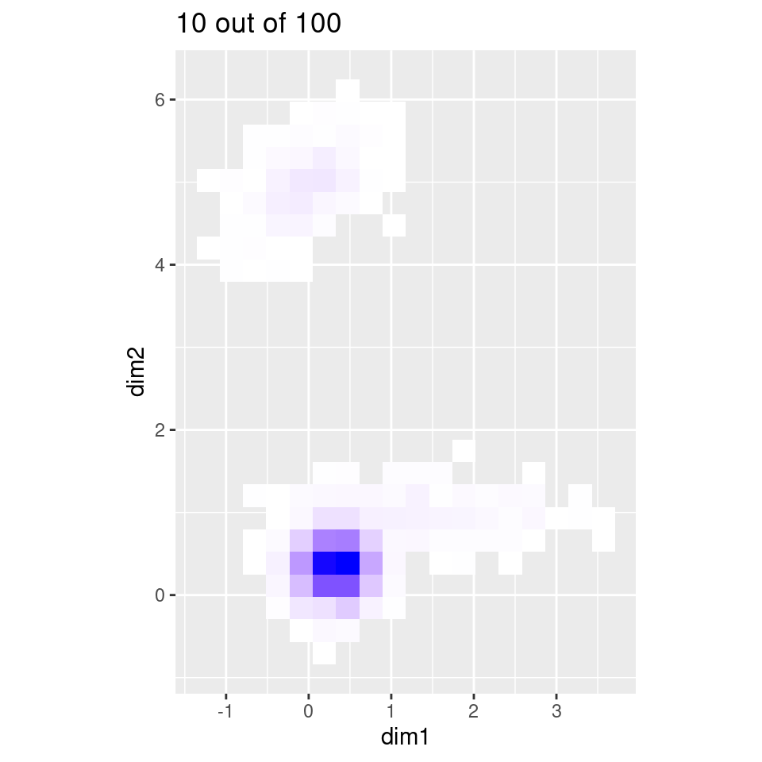

```r
## Plot it
varname1 = colnames(y)[1]
varname2 = colnames(y)[2]
colours = c("white", "blue")
p = ggplot(y) +
  geom_tile(aes(x = !!sym(varname1), y = !!sym(varname2), fill = counts)) +
  theme_grey() +
  scale_fill_gradientn(colours = colours, guide="colorbar") +
  theme(legend.position = "none") +
  coord_fixed() +
  ggtitle(paste0(tt, " out of ", 100))
plot(p)
```

Now, estimating a model on the binned data:

```r
## Run the algorithm on binned data
numclust = 4
res = flowmix(ylist = ylist,
              X = X,
              countslist = countslist,
              numclust = numclust,
              mean_lambda = 0.001,
              prob_lambda = 0.001,
              verbose = FALSE,
              maxdev = 0.5)
print(res)
```

```
#> [1] "37 out of 60 regression coefficients for the cluster centers, are zero."
#> [1] "18 out of 20 regression coefficients for the cluster probabilities, are zero."
#> [1] "The algorithm converged in 13 EM iterations."
```

And finally overlaying the model on the binned data:

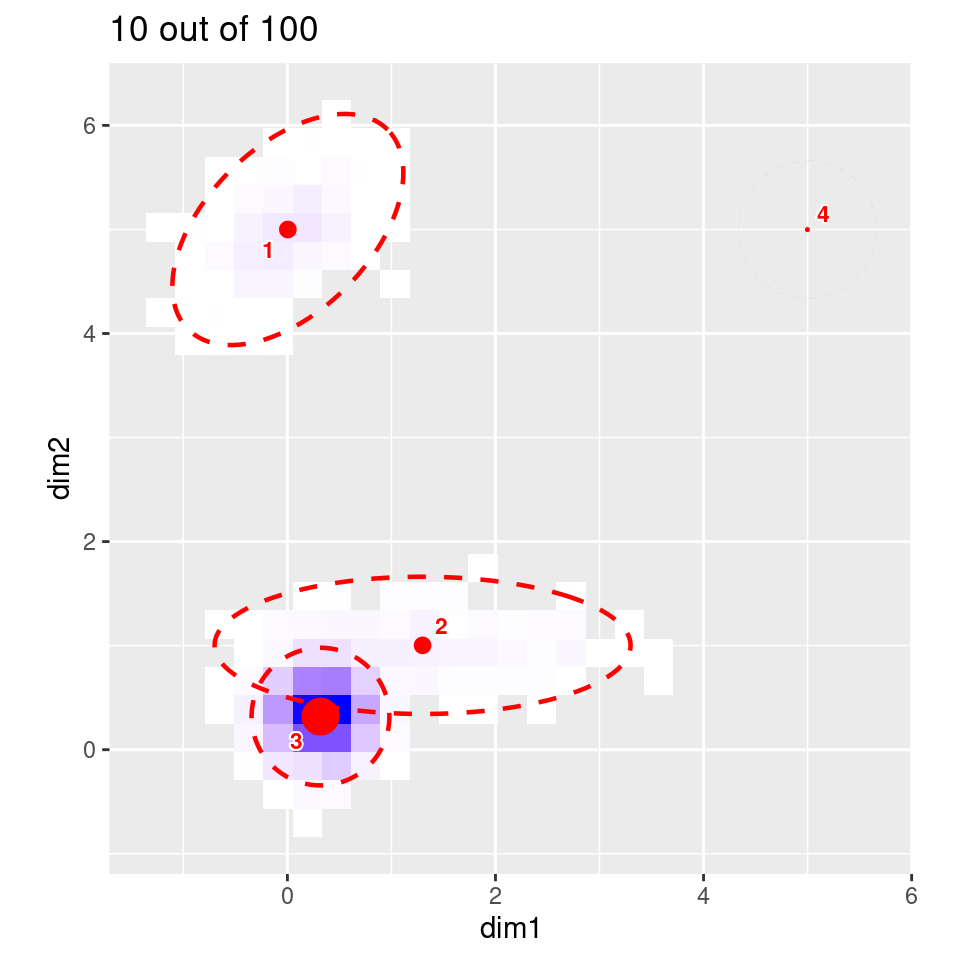

```r
## Add model
mn = res$mn[tt,dims,]
sigma = res$sigma[,dims, dims]
prob = res$prob[tt,]
p = add_model_2d(p, mn, sigma, prob)
plot(p)
```

## 5.2 EM algorithm = one job

It’s useful to understand how the cross-validation is done. The key is to parallelize into multiple CPU cores on a single computer, or even among many different computers or servers.

One “job” (using the function `one_job(ialpha, ibeta, ifold, irep)`) is to run the EM algorithm once, for:

- the `ialpha`-th $\lambda_\alpha$ value (out of `prob_lambdas`).
- the `ibeta`-th $\lambda_\alpha$ value (out of `mean_lambdas`).
- the `ifold`-th test fold out of the `nfold=5` CV folds.
- the `irep`-th repeat of the EM algorithm (`nrep=10` in total)

After each job is run, the result is saved in a file named like `[ialpha]-[ibeta]-[ifold]-[irep]-cvscore.Rdata`.

```r
## Example of one CV job for one pair of regularization parameters (and CV folds
## and EM replicates)
ialpha = 1
ibeta = 1
ifold = 1
irep = 1
destin = "~/Desktop"## Change to your target destination.
one_job(ialpha = ialpha,
        ibeta = ibeta,
        ifold = ifold,
        irep = irep,
        folds = folds,
        destin = destin,
        mean_lambda = mean_lambdas, prob_lambdas = prob_lambdas,
        ## The rest that is needed explicitly for flowmix()
        ylist = ylist,
        countslist = NULL,
        X = X,
        numclust = 4,
        maxdev = 0.5)
```

The above call to `one_job()` saves one file to `1-1-1-1-cvscore.Rdata` to `destin = "~/Desktop"`.

Next, the `nrep` estimated models for any given `ialpha` and `ibeta` – estimated in the full data – are obtained using `one_job_refit()` (again, saving to files named `[ialpha]-[ibeta]-[irep]-cvscore.Rdata`):

```r
## Example of one replicate of model estimation (in the full data) for one pair
## of regularization parameters.
ialpha = 1
ibeta = 1
irep = 1
destin = "~/Desktop"## Change to your target destination.
one_job_refit(ialpha = ialpha,
              ibeta = ibeta,
              irep = irep,
              destin = destin,
              mean_lambda = mean_lambdas, prob_lambdas = prob_lambdas,
              ## The rest that is needed explicitly for flowmix()
              ylist = ylist,
              countslist = NULL,
              X = X,
              numclust = 4,
              maxdev = 0.5,
              )
```

It’s recommended to use multiple computers or servers for the full cross-validation, e.g. using `parallel::mclapply()`.